# assignment02

Weijia Hu

2020/9/23

```r
library(data.table)
library(leaflet)
library(tidyverse)
library(dplyr)
```

# Data Wrangling

### Merge the data

```r
indi <- data.table::fread("E:/566/aasignment2/chs_individual.txt")
regi <- data.table::fread("E:/566/aasignment2/chs_regional.txt")
dat <- merge(x=indi,y=regi,
           by.x="townname", by.y="townname",
           all.x=TRUE,all.y=FALSE)
```

```r
dat[,bmi_mh:=mean(bmi,na.rm=TRUE),by=.(male, hispanic)]
dat[,fev_mh:=mean(fev,na.rm=TRUE),by=.(male, hispanic)]

dat[,bmi:=ifelse(is.na(bmi),bmi_mh,bmi)]
dat[,fev:=ifelse(is.na(fev),fev_mh,fev)]
```

### 1. After merging the data, make sure you don’t have any duplicates by counting the number of rows. Make sure it matches.

```r
nrow(dat) == nrow(indi)
```

```
## [1] TRUE
```

### 2.Create a new categorical variable named “obesity_level” using the BMI measurement (underweight BMI<14; normal BMI 14-22; overweight BMI 22-24; obese BMI>24). To make sure the variable is rightly coded, create a summary table that contains the minimum BMI, maximum BMI, and the total number of observations per category.

```r
dat[bmi<14, obesity_level := "underweight"]
dat[bmi>=14 & bmi<22, obesity_level := "normal"]
dat[bmi>=22 & bmi<24, obesity_level := "overweight"]
dat[bmi>=24, obesity_level := "obese"]

dat[,.(
  bmi_min = min(bmi, na.rm=T),
  bmi_max = max(bmi, na.rm=T),
  n= length(bmi)
),by =  obesity_level] [order( obesity_level)]
```

```
##    obesity_level  bmi_min  bmi_max   n
## 1:        normal 14.00380 21.96387 975
## 2:         obese 24.00647 41.26613 103
## 3:    overweight 22.02353 23.99650  87
## 4:   underweight 11.29640 13.98601  35
```

### 3.Create another categorical variable named “smoke_gas_exposure” that summarizes “Second Hand Smoke” and “Gas Stove.” The variable should have four categories in total.

```r
dat[smoke==0 & gasstove ==0, smoke_gas_exposure := "1"]
dat[smoke==1 & gasstove ==0, smoke_gas_exposure := "2"]
dat[smoke==0 & gasstove ==1, smoke_gas_exposure := "3"]
dat[smoke==1 & gasstove ==1, smoke_gas_exposure := "4"]
dat[,.(
   n= length(smoke)
), by = smoke_gas_exposure][order( smoke_gas_exposure)]
```

```
##    smoke_gas_exposure   n
## 1:                  1 214
## 2:                  2  36
## 3:                  3 739
## 4:                  4 151
## 5:               <NA>  60
```

```r
#Townname
dat[,.(
   fev_mean = mean(fev, na.rm=T),
   fev_sd = sd(fev, na.rm=T)
), by = townname][order(townname)]
```

```
##          townname fev_mean   fev_sd
##  1:        Alpine 2087.101 291.1768
##  2:    Atascadero 2075.897 324.0935
##  3: Lake Elsinore 2038.849 303.6956
##  4:  Lake Gregory 2084.700 319.9593
##  5:     Lancaster 2003.044 317.1298
##  6:        Lompoc 2034.354 351.0454
##  7:    Long Beach 1985.861 319.4625
##  8:     Mira Loma 1985.202 324.9634
##  9:     Riverside 1989.881 277.5065
## 10:     San Dimas 2026.794 318.7845
## 11:   Santa Maria 2025.750 312.1725
## 12:        Upland 2024.266 343.1637
```

```r
#Sex
dat[,.(
   fev_mean = mean(fev, na.rm=T),
   fev_sd = sd(fev, na.rm=T)
), by = male][order(male)]
```

```
##    male fev_mean   fev_sd
## 1:    0 1958.911 311.9181
## 2:    1 2103.787 307.5123
```

```r
#Obesity level
dat[,.(
   fev_mean = mean(fev, na.rm=T),
   fev_sd = sd(fev, na.rm=T)
), by = obesity_level][order(obesity_level)]
```

```
##    obesity_level fev_mean   fev_sd
## 1:        normal 1999.794 295.1964
## 2:         obese 2266.154 325.4710
## 3:    overweight 2224.322 317.4261
## 4:   underweight 1698.327 303.3983
```

```r
#smoke_gas_exposure
dat[,.(
   fev_mean = mean(fev, na.rm=T),
   fev_sd = sd(fev, na.rm=T)
), by = smoke_gas_exposure][order(smoke_gas_exposure)]
```

```
##    smoke_gas_exposure fev_mean   fev_sd
## 1:                  1 2055.356 330.4169
## 2:                  2 2055.714 295.6475
## 3:                  3 2025.989 317.6305
## 4:                  4 2019.867 298.9728
## 5:               <NA> 2001.878 340.2592
```

# Looking at the Data (EDA)

### 1. Facet plot showing scatterplots with regression lines of BMI vs FEV by “townname”.

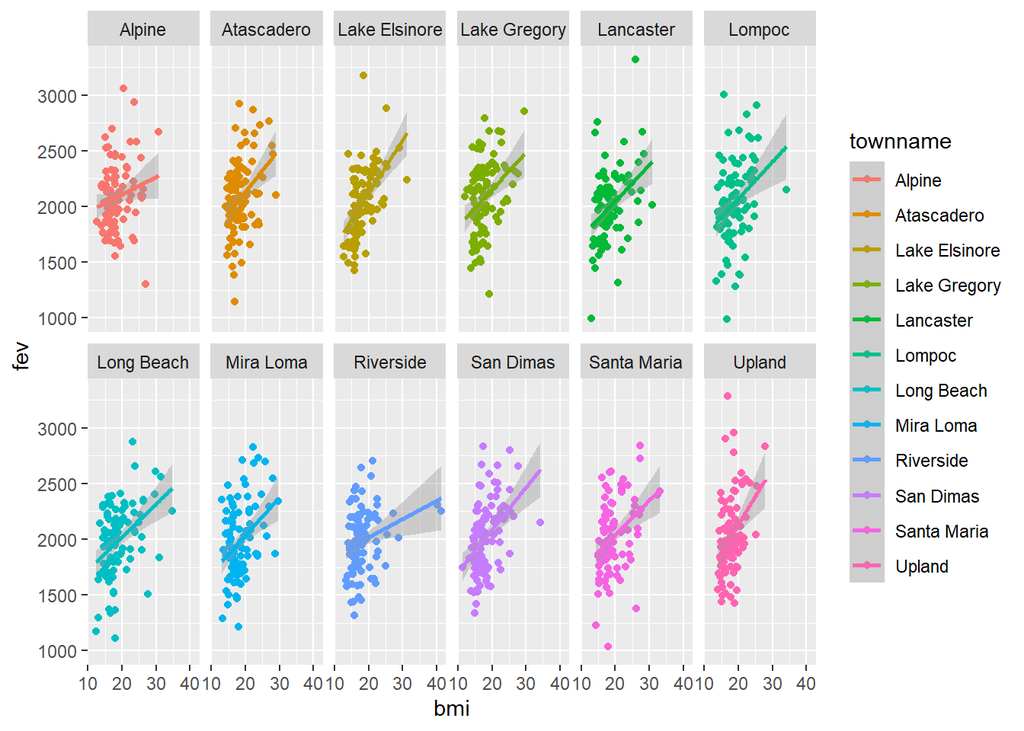

```r
dat %>%
  filter(!(townname %in% NA)) %>%
  ggplot(mapping = aes(x= bmi, y=fev, color=townname))+
  geom_point(mapping=aes(color=townname))+
  stat_smooth(method = lm)+
  facet_wrap(~townname, nrow=2)
```

### 2.Stacked histograms of FEV by BMI category and FEV by smoke/gas exposure. Use different color schemes than the ggplot default.

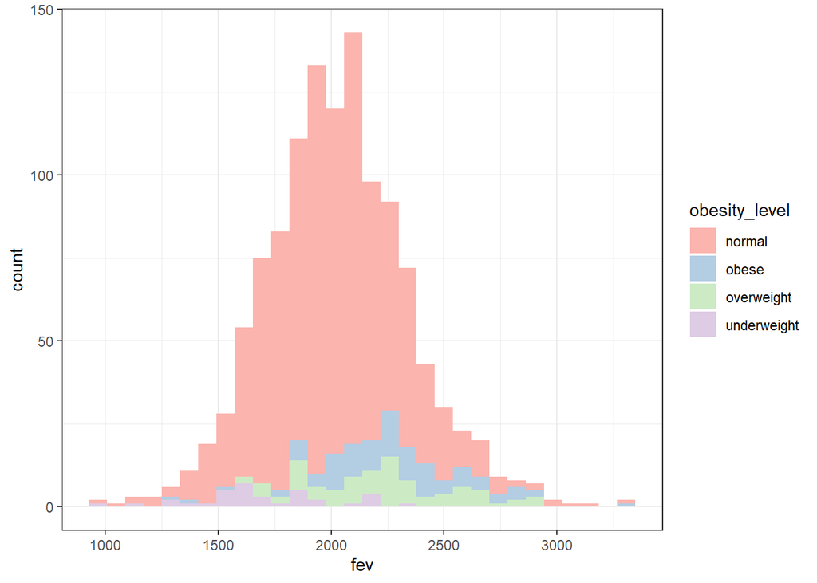

```r
#The histogram of FEV by BMI category
dat %>%
  filter(!(obesity_level %in% NA)) %>%
  ggplot()+
  geom_histogram(mapping = aes(x = fev, fill=obesity_level))+
  scale_fill_brewer(palette = "Pastel1")+
  theme_bw()
```

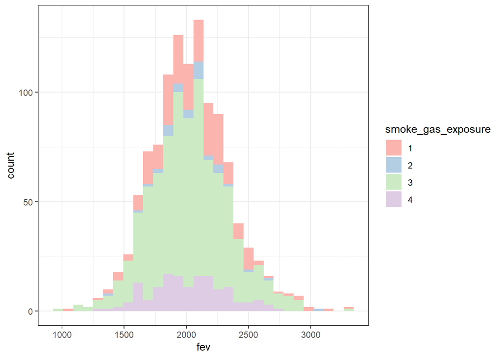

```r
#The histogram of FEV by smoke/gas exposure
dat %>%
  filter(!(smoke_gas_exposure %in% NA)) %>%
  ggplot()+
  geom_histogram(mapping = aes(x = fev, fill=smoke_gas_exposure))+
  scale_fill_brewer(palette = "Pastel1")+
  theme_bw()
```

### 3. Barchart of BMI by smoke/gas exposure.

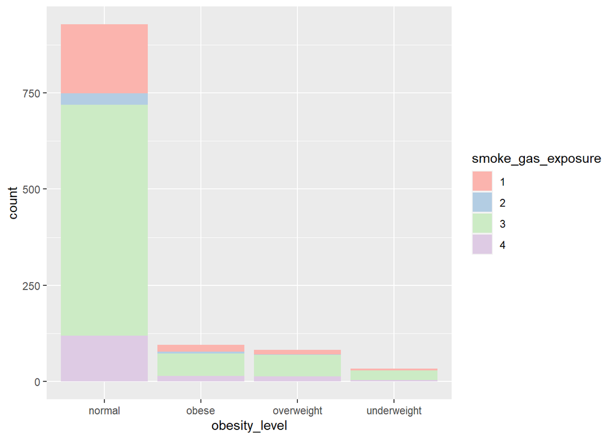

```r
dat %>%
  filter(!(smoke_gas_exposure %in% NA)) %>%
  ggplot()+
  geom_bar(mapping = aes(x= obesity_level, fill=smoke_gas_exposure))+
  scale_fill_brewer(palette = "Pastel1")
```

### 4. Statistical summary graphs of FEV by BMI and FEV by smoke/gas exposure category.

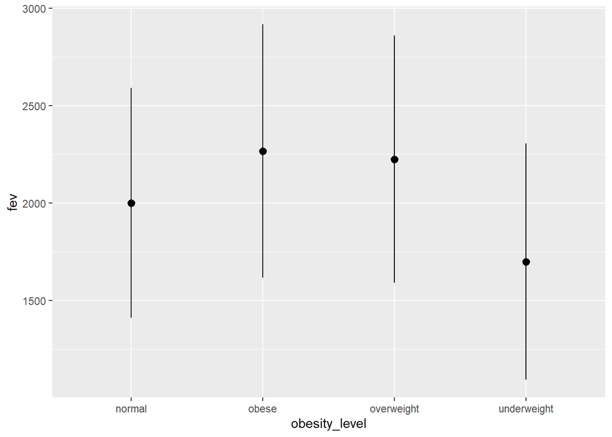

```r
dat %>%
  ggplot(mapping=aes(x=obesity_level, y=fev))+
  stat_summary(fun.data="mean_sdl")
```

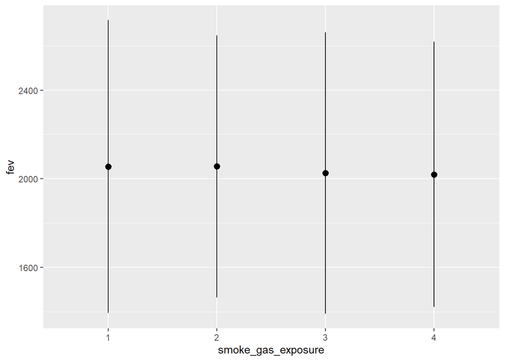

```r
dat %>%
  filter(!(smoke_gas_exposure %in% NA)) %>%
  ggplot(mapping=aes(x=smoke_gas_exposure, y=fev))+
  stat_summary(fun.data="mean_sdl")
```

### 5. A leaflet map showing the concentrations of PM2.5 mass in each of the CHS communities.

```r
dat2<-dat[!is.na(pm25_mass)]
pm25_pal = colorNumeric(c('darkgreen','goldenrod','brown'), domain=dat2$pm25_mass)
leaflet(dat2)%>%
  addProviderTiles("OpenStreetMap")%>%
  addCircles(lat=~lat,lng=~lon,color=~pm25_pal(pm25_mass),opacity=1,fillOpacity=1, radius=5000)%>%
addLegend("bottomleft", pal=pm25_pal,values =dat2$pm25_mass, title="concentration of PM2.5 Mass", opacity=1)
```

[interactive chart not shown]

### 6. Choose a visualization to examine whether PM2.5 mass is associated with FEV.

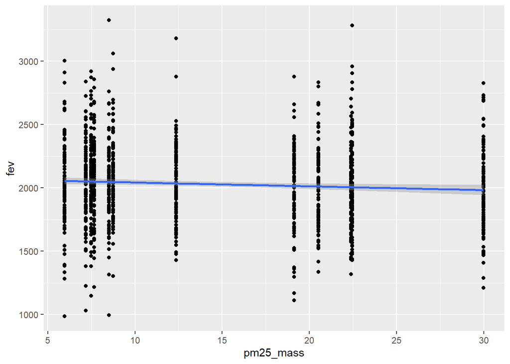

```r
dat %>%
  filter(!(pm25_mass %in% NA)) %>%
  ggplot(mapping = aes(x= pm25_mass, y=fev))+
  geom_point()+
  stat_smooth(method = lm)
```

### The primary questions of interest are:

1. What is the association between BMI and FEV (forced expiratory volume)?

-Based on the question 1, there is a positive association between BMI and FEV among these towns.

2. What is the association between smoke and gas exposure and FEV?

3. What is the association between PM2.5 exposure and FEV?

-According to the last question, the regression line is almost horizontal. We could say that there is a weak negative association between PM2.5 exposure and FEV. But I’d rather conclude that there is no association between PM2.5 exposure and FEV.